# Model Diagnostics and Posterior Predictive Check: Main Model

```r
pacman::p_load(MetaStan, cmdstanr, dplyr, tidyr, rio, here, data.table,
               posterior, ggdist, ggplot2, bayesplot)

# Set Stan options
options(mc.cores = parallel::detectCores())
color_scheme_set("red")
```

# Data

```r
dat = import(here("data/raw_data.xlsx"))

setnames(dat, old=c("Int_Events","Control_Events"), new=c("r2", "r1"))
setnames(dat, old=c("Int_Total","Control_Total"), new=c("n2", "n1"))

J <- nrow(dat)  # Number of studies (84)
y <- as.matrix(dat[, c("r1", "r2")])  # Events: control (r1), treatment (r2)
sample <- as.matrix(dat[, c("n1", "n2")])  # Sample sizes: control (n1), treatment (n2)
zero <- c(0, 0)  # Zero vector for random effects mean

# Create the Stan data list
stan_data <- list(
  J = J,
  zero = zero,
  y = y,
  sample = sample
)
```

# Model

```r
# Compile the Stan model
zibglmm1 <- cmdstan_model(here("models/stan/zibglmm_model1.stan"))
```

```r
csv_files <- list.files(here("models/storage"),
                        pattern = "^zibglmm_model1.*\\.csv$",
                        full.names = TRUE)

if (length(csv_files) > 0 && all(file.exists(csv_files))) {
  # Load the fit1 from CSV files
  fit1 <- cmdstanr::as_cmdstan_fit(csv_files)

} else {
  # fit1 the model if no CSV files are found
  fit1 <- zibglmm1$sample(
    data = stan_data,
    chains = 4,
    parallel_chains = 4,
    iter_warmup = 2000,
    iter_sampling = 2000,
    adapt_delta = 0.99,
    max_treedepth = 15,
    seed = 123,
    refresh = 0
)

  # Save CSV files to persistent directory
  fit1$save_output_files(dir = "models/storage")
}
```

# Diagnostics

```r
draws_diagnostics <- fit1$draws(variables = c("mu", "sigma_nu", "pi"))

summary_df <- fit1$summary(variables = c("mu", "sigma_nu", "pi"))

print(summary_df[, c("variable", "ess_bulk", "ess_tail", "rhat")])
```

```
# A tibble: 5 × 4
  variable    ess_bulk ess_tail  rhat
  <chr>          <dbl>    <dbl> <dbl>
1 mu[1]          2969.    4505.  1.00
2 mu[2]          3154.    4249.  1.00
3 sigma_nu[1]    5423.    5747.  1.00
4 sigma_nu[2]    4308.    5345.  1.00
5 pi             6538.    5124.  1.00
```

```r
fit1$diagnostic_summary()
```

```
$num_divergent
[1] 0 0 0 0

$num_max_treedepth
[1] 0 0 0 0

$ebfmi
[1] 0.9719985 0.9386688 0.9758205 0.9859635
```

Check for convergence and mixing of chains

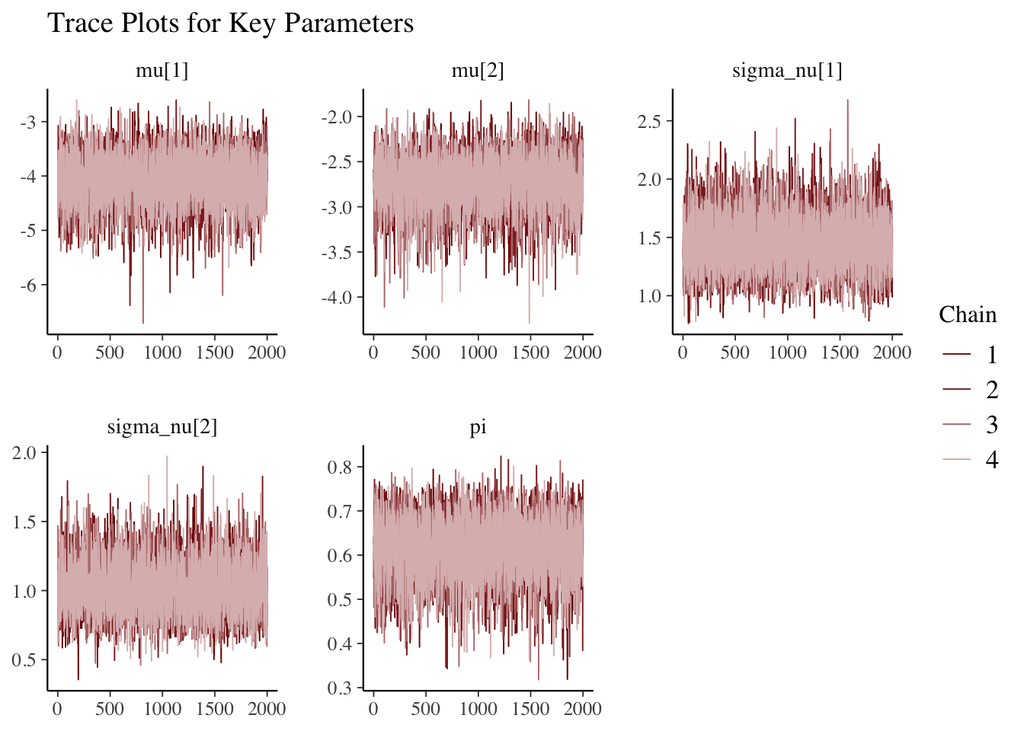

```r
mcmc_trace(draws_diagnostics, pars = c("mu[1]", "mu[2]", "sigma_nu[1]", "sigma_nu[2]", "pi")) +
  ggtitle("Trace Plots for Key Parameters")
```

Check autocorrelation for key parameters

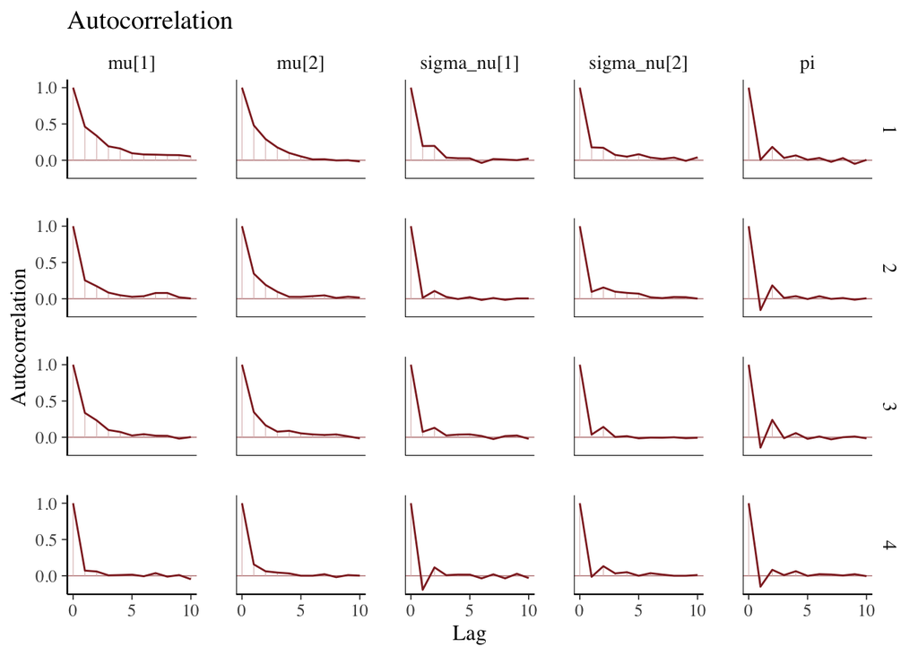

```r
mcmc_acf(draws_diagnostics, pars = c("mu[1]", "mu[2]", "sigma_nu[1]",
                                     "sigma_nu[2]", "pi"), lags = 10) +
  ggtitle("Autocorrelation")
```

# Posterior Predictive Check

A posterior predictive check (PPC) is a Bayesian method used to assess how well a statistical model fits the observed data by comparing it to data simulated from the model. It involves generating replicated datasets ($y_{\text{rep}}$) from the posterior predictive distribution, which combines the fitted model parameters with new random noise. Test statistics (e.g., means, variances, or proportions) are computed for both the observed data ($y_{\text{obs}}$) and the replicated data. By comparing these statistics—through visualizations (e.g., histograms) or numerical summaries (e.g., posterior p-values)—PPCs evaluate whether the model can reproduce key features of the data. If the observed statistics align with the replicated ones, the model is considered a good fit1; significant discrepancies suggest model misspecification.

Posterior predictive p-values (also called Bayesian p-values) are a useful way to quantify the fit of your model in a posterior predictive check (PPC). They measure the probability that a test statistic computed from the replicated data ($y_{\text{rep}}$) is more extreme than the same test statistic computed from the observed data ($y_{\text{obs}}$). A Bayesian p-value close to 0 or 1 indicates a poor fit, while a value around 0.5 suggests the model captures the observed data well for that statistic.

For a test statistic $T(y)$, the posterior predictive p-value is defined as:

$p = P(T(y_{\text{rep}}) \geq T(y_{\text{obs}}) \mid y_{\text{obs}})$

```r
# Extract observed and replicated data
y_obs <- as.matrix(dat[, c("r1", "r2")])  # Observed data
y_rep <- fit1$draws("y_rep")  # Posterior predictive samples
y_rep <- posterior::as_draws_matrix(y_rep)  # Convert to matrix
```

## 1. Proportion of double zeros

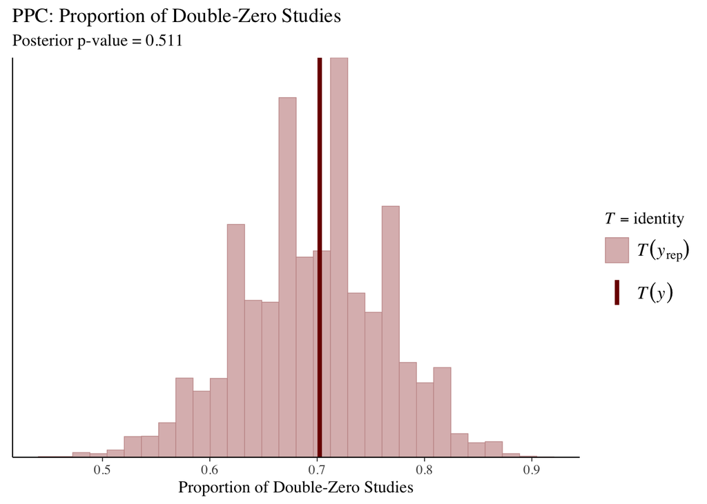

```r
# 1. PPC: Proportion of double zeros
double_zeros_obs <- sum(y_obs[,1] == 0 & y_obs[,2] == 0) / nrow(y_obs)

double_zeros_rep <- apply(y_rep, 1, function(y) {
  y_mat <- matrix(y, nrow = J, ncol = 2)
  sum(y_mat[,1] == 0 & y_mat[,2] == 0) / J
})

double_zeros_rep <- as.matrix(double_zeros_rep)

p_value_double_zeros <- mean(double_zeros_rep >= double_zeros_obs)

ppc_stat(double_zeros_obs, double_zeros_rep, stat = "identity") +
  ggtitle("PPC: Proportion of Double-Zero Studies") +
  labs(subtitle = paste("Posterior p-value =", round(p_value_double_zeros, 3))) +
  xlab("Proportion of Double-Zero Studies")
```

## 2. Mean event rates

```r
mean_rate_control_obs <- mean(y_obs[,1] / dat$n1)

mean_rate_treatment_obs <- mean(y_obs[,2] / dat$n2)

mean_rate_control_rep <- apply(y_rep, 1, function(y) {
  y_mat <- matrix(y, nrow = J, ncol = 2)
  mean(y_mat[,1] / dat$n1)
})

mean_rate_treatment_rep <- apply(y_rep, 1, function(y) {
  y_mat <- matrix(y, nrow = J, ncol = 2)
  mean(y_mat[,2] / dat$n2)
})

mean_rate_control_rep <- as.matrix(mean_rate_control_rep)

mean_rate_treatment_rep <- as.matrix(mean_rate_treatment_rep)

p_value_mean_rate_control <- mean(mean_rate_control_rep >= mean_rate_control_obs)

p_value_mean_rate_treatment <- mean(mean_rate_treatment_rep >= mean_rate_treatment_obs)
```

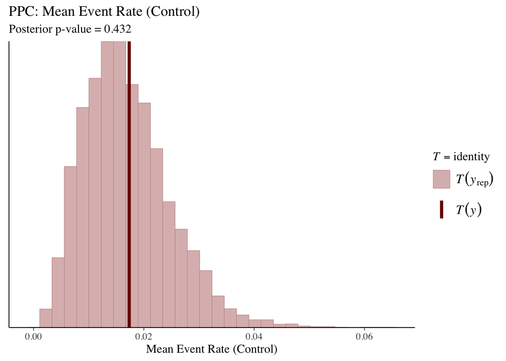

```r
ppc_stat(mean_rate_control_obs, mean_rate_control_rep, stat = "identity") +
  ggtitle("PPC: Mean Event Rate (Control)") +
  labs(subtitle = paste("Posterior p-value =", round(p_value_mean_rate_control, 3))) +
  xlab("Mean Event Rate (Control)")
```

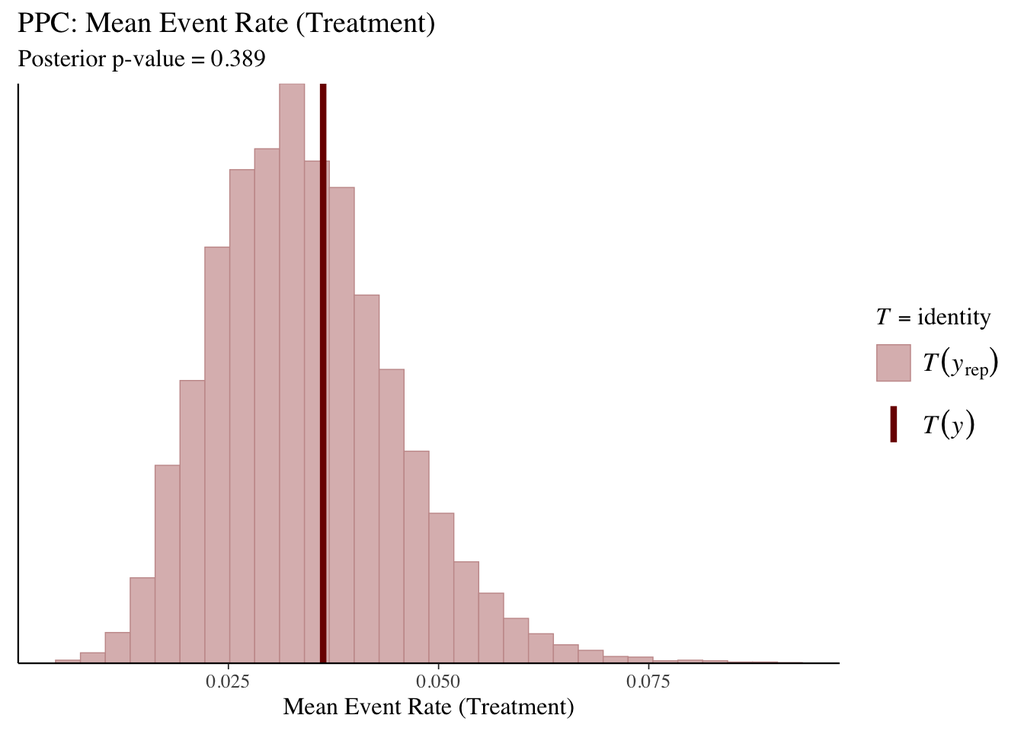

```r
ppc_stat(mean_rate_treatment_obs, mean_rate_treatment_rep, stat = "identity") +
  ggtitle("PPC: Mean Event Rate (Treatment)") +
  labs(subtitle = paste("Posterior p-value =", round(p_value_mean_rate_treatment, 3))) +
  xlab("Mean Event Rate (Treatment)")
```

## 3. Total event counts

```r
total_events_control_obs <- sum(y_obs[,1])

total_events_treatment_obs <- sum(y_obs[,2])

total_events_control_rep <- apply(y_rep, 1, function(y) {
  y_mat <- matrix(y, nrow = J, ncol = 2)
  sum(y_mat[,1])
})

total_events_treatment_rep <- apply(y_rep, 1, function(y) {
  y_mat <- matrix(y, nrow = J, ncol = 2)
  sum(y_mat[,2])
})

total_events_control_rep <- as.matrix(total_events_control_rep)

total_events_treatment_rep <- as.matrix(total_events_treatment_rep)

p_value_total_control <- mean(total_events_control_rep >= total_events_control_obs)

p_value_total_treatment <- mean(total_events_treatment_rep >= total_events_treatment_obs)
```

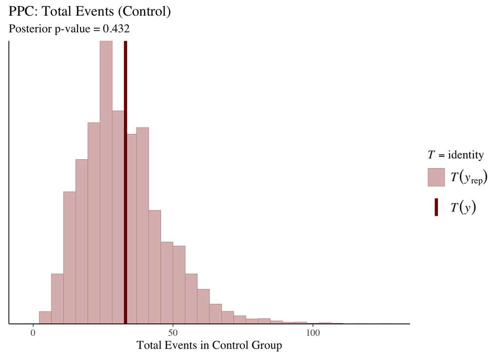

```r
ppc_stat(total_events_control_obs, total_events_control_rep, stat = "identity") +
  ggtitle("PPC: Total Events (Control)") +
  labs(subtitle = paste("Posterior p-value =", round(p_value_total_control, 3))) +
  xlab("Total Events in Control Group")
```

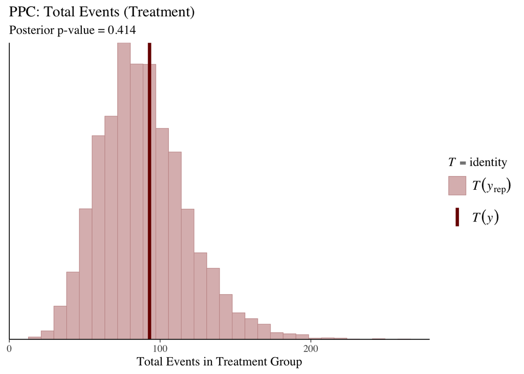

```r
ppc_stat(total_events_treatment_obs, total_events_treatment_rep, stat = "identity") +
  ggtitle("PPC: Total Events (Treatment)") +
  labs(subtitle = paste("Posterior p-value =", round(p_value_total_treatment, 3))) +
  xlab("Total Events in Treatment Group")
```

## 4. Proportion of zero events per arm

```r
prop_zeros_control_obs <- mean(y_obs[,1] == 0)

prop_zeros_treatment_obs <- mean(y_obs[,2] == 0)

prop_zeros_control_rep <- apply(y_rep, 1, function(y) {
  y_mat <- matrix(y, nrow = J, ncol = 2)
  mean(y_mat[,1] == 0)
})

prop_zeros_treatment_rep <- apply(y_rep, 1, function(y) {
  y_mat <- matrix(y, nrow = J, ncol = 2)
  mean(y_mat[,2] == 0)
})

prop_zeros_control_rep <- as.matrix(prop_zeros_control_rep)

prop_zeros_treatment_rep <- as.matrix(prop_zeros_treatment_rep)

p_value_prop_zeros_control <- mean(prop_zeros_control_rep >= prop_zeros_control_obs)

p_value_prop_zeros_treatment <- mean(prop_zeros_treatment_rep >= prop_zeros_treatment_obs)
```

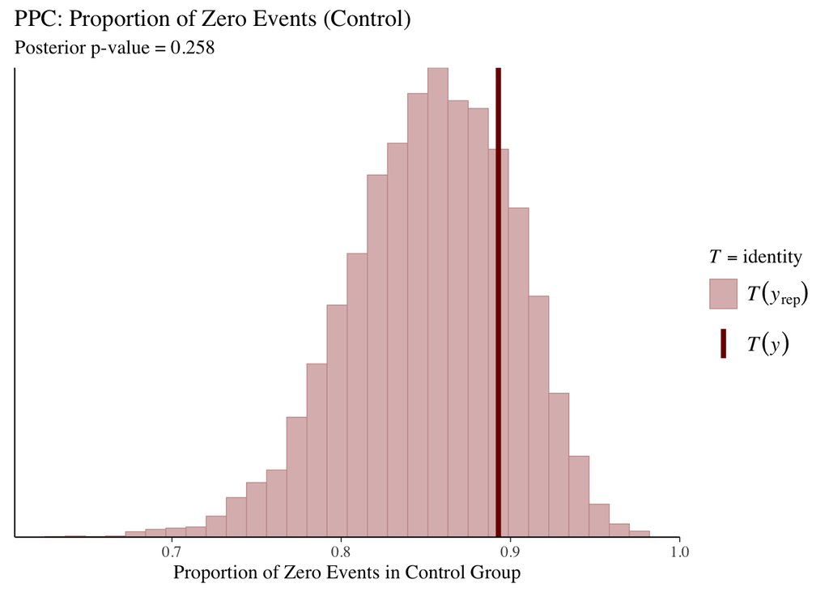

```r
ppc_stat(prop_zeros_control_obs, prop_zeros_control_rep, stat = "identity") +
  ggtitle("PPC: Proportion of Zero Events (Control)") +
  labs(subtitle = paste("Posterior p-value =", round(p_value_prop_zeros_control, 3))) +
  xlab("Proportion of Zero Events in Control Group")
```

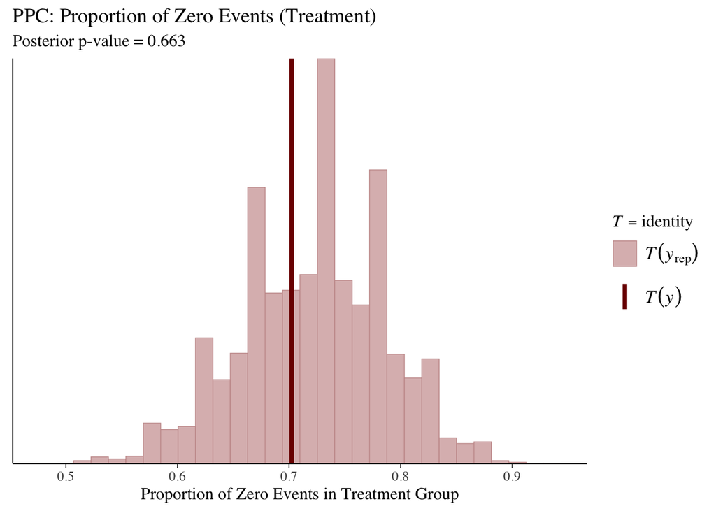

```r
ppc_stat(prop_zeros_treatment_obs, prop_zeros_treatment_rep, stat = "identity") +
  ggtitle("PPC: Proportion of Zero Events (Treatment)") +
  labs(subtitle = paste("Posterior p-value =", round(p_value_prop_zeros_treatment, 3))) +
  xlab("Proportion of Zero Events in Treatment Group")
```

## 5. Variance of event rates

```r
var_rate_control_obs <- var(y_obs[,1] / dat$n1)

var_rate_treatment_obs <- var(y_obs[,2] / dat$n2)

var_rate_control_rep <- apply(y_rep, 1, function(y) {
  y_mat <- matrix(y, nrow = J, ncol = 2)
  var(y_mat[,1] / dat$n1)
})

var_rate_treatment_rep <- apply(y_rep, 1, function(y) {
  y_mat <- matrix(y, nrow = J, ncol = 2)
  var(y_mat[,2] / dat$n2)
})

var_rate_control_rep <- as.matrix(var_rate_control_rep)

var_rate_treatment_rep <- as.matrix(var_rate_treatment_rep)

p_value_var_rate_control <- mean(var_rate_control_rep >= var_rate_control_obs)

p_value_var_rate_treatment <- mean(var_rate_treatment_rep >= var_rate_treatment_obs)
```

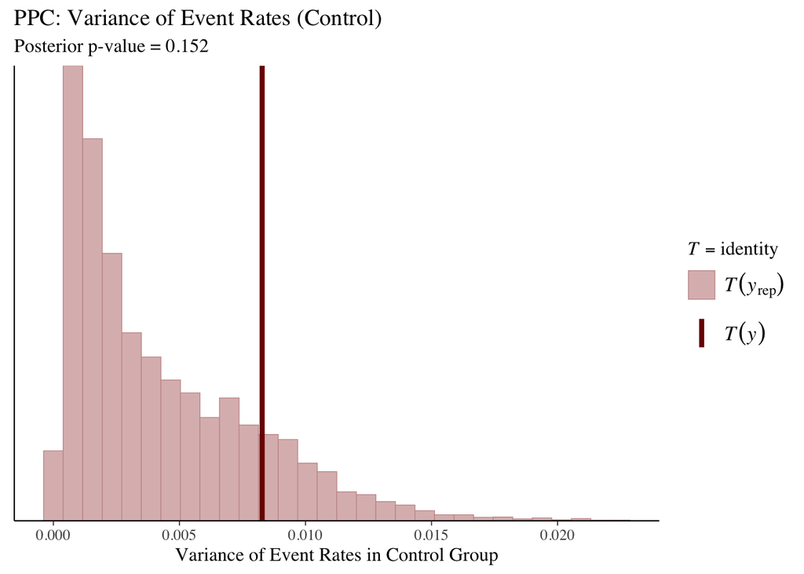

```r
ppc_stat(var_rate_control_obs, var_rate_control_rep, stat = "identity") +
  ggtitle("PPC: Variance of Event Rates (Control)") +
  labs(subtitle = paste("Posterior p-value =", round(p_value_var_rate_control, 3))) +
  xlab("Variance of Event Rates in Control Group")
```

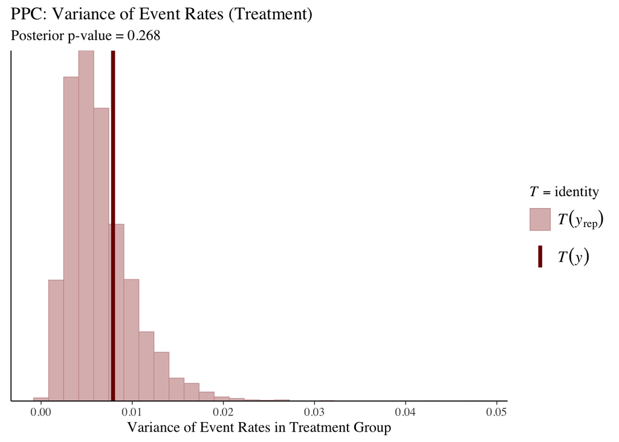

```r
ppc_stat(var_rate_treatment_obs, var_rate_treatment_rep, stat = "identity") +
  ggtitle("PPC: Variance of Event Rates (Treatment)") +
  labs(subtitle = paste("Posterior p-value =", round(p_value_var_rate_treatment, 3))) +
  xlab("Variance of Event Rates in Treatment Group")
```

## 6. Correlation between Control and Treatment Event Proportions

```r
# Compute observed correlation
p_control_obs <- y_obs[,1] / dat$n1
p_treatment_obs <- y_obs[,2] / dat$n2
corr_obs <- cor(p_control_obs, p_treatment_obs)

# Compute correlation for replicated data
corr_rep <- apply(y_rep, 1, function(y) {
  y_mat <- matrix(y, nrow = J, ncol = 2)
  p_control_rep <- y_mat[,1] / dat$n1
  p_treatment_rep <- y_mat[,2] / dat$n2
  cor(p_control_rep, p_treatment_rep)
})

# Convert to matrix for ppc_stat
corr_rep <- as.matrix(corr_rep)

# Compute posterior p-value
p_value_corr <- mean(corr_rep >= corr_obs)
```

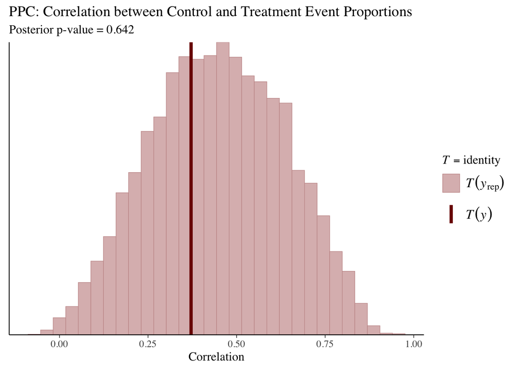

```r
# Generate PPC plot
ppc_stat(corr_obs, corr_rep, stat = "identity") +
  ggtitle("PPC: Correlation between Control and Treatment Event Proportions") +
  labs(subtitle = paste("Posterior p-value =", round(p_value_corr, 3))) +
  xlab("Correlation")
```

## 7. Predicted Study-Specific Control/Treatment Probabiltities

This plots shows the predicted probability density for each study as heatmaps. Each row represents a study in our sample. Red points depict the observed study-specific probability.

```r
draws1 <- fit1$draws(format = "df")

# Compute study-specific probabilities
empirical_probabilities =
  dat |> reframe(Study = factor(1:nrow(dat)), p1 = r1/n1, p2 = r2/n2)

J <- nrow(dat)  # Number of studies (match your data)
n_samples <- nrow(draws1)  # Adjust based on number of chains and iterations
p_control_n <- matrix(NA, n_samples, J)
p_treatment_n <- matrix(NA, n_samples, J)

# Extract mu and nu from draws (adjust column names based on your model output)
mu_control <- draws1$`mu[1]`
mu_treatment <- draws1$`mu[2]`

for (j in 1:J) {
  nu_control_j <- draws1[[paste0("nu[", j, ",1]")]]
  nu_treatment_j <- draws1[[paste0("nu[", j, ",2]")]]

  p_control_n[, j] <- plogis(mu_control + nu_control_j)
  p_treatment_n[, j] <- plogis(mu_treatment + nu_treatment_j)
}

control_long <- data.frame(
  Probability = as.vector(p_control_n),
  Study = factor(rep(1:J, each = nrow(p_control_n))),
  Group = "Control"
)

treatment_long <- data.frame(
  Probability = as.vector(p_treatment_n),
  Study = factor(rep(1:J, each = nrow(p_treatment_n))),
  Group = "Treatment"
)
```

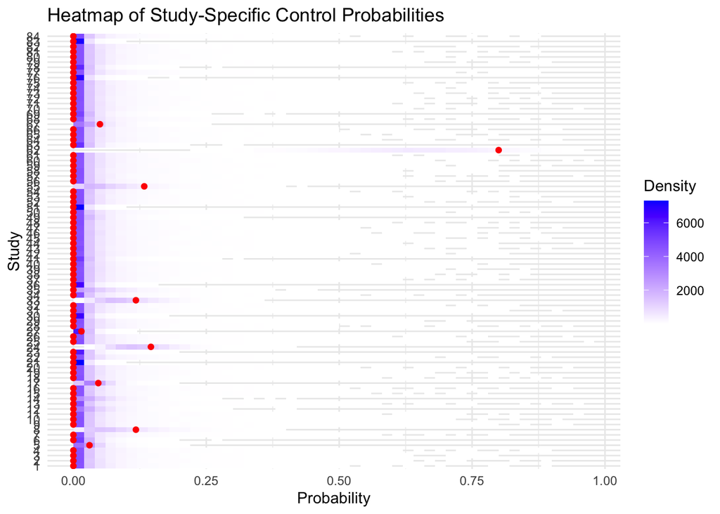

```r
ggplot(control_long, aes(x = Probability, y = Study)) +
  geom_bin2d(binwidth = c(0.02, 1)) +
  scale_fill_gradient(low = "white", high = "blue") +

  geom_point(data = empirical_probabilities,
             aes(x = p1, y = Study), color = "red") +
  labs(title = "Heatmap of Study-Specific Control Probabilities",
       x = "Probability",
       y = "Study",
       fill = "Density") +
  theme_minimal() +
  theme(strip.text = element_text(size = 12, face = "bold"))
```

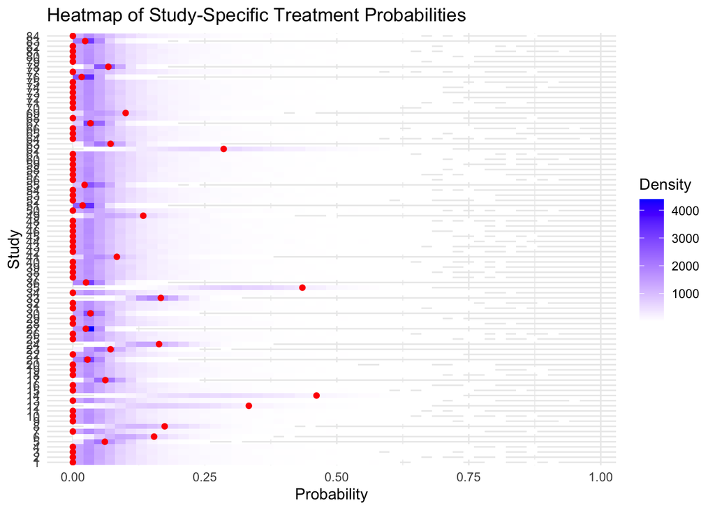

```r
ggplot(treatment_long, aes(x = Probability, y = Study)) +
  geom_bin2d(binwidth = c(0.02, 1)) +
  scale_fill_gradient(low = "white", high = "blue") +
  geom_point(data = empirical_probabilities,
             aes(x = p2, y = Study), color = "red") +
  labs(title = "Heatmap of Study-Specific Treatment Probabilities",
       x = "Probability",
       y = "Study",
       fill = "Density") +
  theme_minimal() +
  theme(strip.text = element_text(size = 12, face = "bold"))
```